# Chương 6: Máy Điện DC

## I. Tổng Quan

### 1. Giới thiệu và Ứng dụng

- **Lý thuyết:** Máy điện một chiều (DC Machines) là loại máy điện đã có lịch sử phát triển lâu đời và vẫn giữ vai trò quan trọng trong nhiều lĩnh vực. Chúng có thể hoạt động ở chế độ máy phát (biến cơ năng thành điện năng một chiều) hoặc động cơ (biến điện năng một chiều thành cơ năng). Các ứng dụng tiêu biểu bao gồm:
  - Động cơ: Xe điện (xe golf, xe nâng), thang máy, cần cẩu, máy cán thép, các hệ thống truyền động đòi hỏi điều khiển tốc độ và moment chính xác (như trong robot công nghiệp, máy công cụ CNC trước đây), động cơ khởi động ô tô,...
  - Máy phát: Các nguồn điện một chiều độc lập, máy phát kích từ cho máy phát điện đồng bộ lớn,...

### 2. Cấu tạo cơ bản

- **Lý thuyết:** Máy điện DC điển hình gồm các bộ phận chính sau:
  - **Stator (Phần tĩnh / Phần cảm):**
    - *Vỏ máy (Frame/Yoke):* Thường làm bằng thép đúc hoặc thép tấm, là khung chịu lực và tạo thành mạch dẫn từ cho từ thông kích từ.
    - *Cực từ chính (Main Pole):* Gắn vào vỏ máy, gồm lõi thép cực từ và dây quấn kích từ (Field Winding). Dây quấn kích từ tạo ra từ trường chính ($\Phi_f$) của máy khi có dòng điện chạy qua.
    - *Cực từ phụ (Interpole - nếu có):* Nằm giữa các cực từ chính, giúp cải thiện quá trình đổi chiều dòng điện ở cổ góp.
    - *Cuộn bù (Compensating Winding - nếu có):* Đặt trong các rãnh trên bề mặt cực từ chính, giúp giảm ảnh hưởng của phản ứng phần ứng.
  - **Rotor (Phần quay / Phần ứng):**
    - *Lõi sắt phần ứng (Armature Core):* Ghép từ các lá thép kỹ thuật điện mỏng, cách điện với nhau để giảm tổn hao do dòng xoáy. Lõi sắt có các rãnh dọc trục để đặt dây quấn phần ứng.
    - *Dây quấn phần ứng (Armature Winding):* Gồm nhiều phần tử dây quấn nối với nhau theo quy luật nhất định và nối ra các phiến góp của cổ góp. Đây là nơi sức điện động được cảm ứng (máy phát) hoặc nơi dòng điện chạy qua tạo ra moment quay (động cơ).
    - *Cổ góp (Commutator):* Gồm nhiều phiến đồng (lam đồng) hình rẻ quạt, ghép thành hình trụ và cách điện với nhau cũng như với trục. Các đầu dây của phần tử dây quấn phần ứng được hàn vào các phiến góp tương ứng.
    - *Trục máy (Shaft):* Truyền chuyển động quay.
  - **Cơ cấu chổi than (Brush Assembly):**
    - *Chổi than (Carbon Brush):* Thường làm bằng carbon graphite, được giữ trong giá đỡ chổi than và tì lên bề mặt cổ góp nhờ lò xo. Chổi than đứng yên so với vỏ máy, làm nhiệm vụ dẫn điện từ mạch ngoài vào/ra dây quấn phần ứng đang quay thông qua cổ góp.

### 3. Nguyên lý Điện từ cơ bản

Đây là hai định luật vật lý nền tảng giải thích hoạt động của máy điện.

**a. Lực Điện từ (Nguyên lý Động cơ):**

```python
import math

def tinh_luc_dien_tu(I, l, B, alpha_deg=90.0):
  """
  Tính độ lớn lực điện từ tác dụng lên dây dẫn.

  Args:
    I: Cường độ dòng điện (A).
    l: Chiều dài phần dây dẫn trong từ trường (m).
    B: Cảm ứng từ (T - Tesla).
    alpha_deg: Góc giữa dây dẫn và từ trường (độ), mặc định là 90.

  Returns:
    Độ lớn lực điện từ (N) hoặc None nếu lỗi.
  """
  if l <= 0 or B < 0:
      print("Lỗi: Chiều dài (l) phải > 0 và Cảm ứng từ (B) phải >= 0.")
      return None
  alpha_rad = math.radians(alpha_deg)
  # Độ lớn lực không phụ thuộc dấu của I, chỉ phụ thuộc giá trị tuyệt đối
  Fe = abs(I) * l * B * math.sin(alpha_rad)
  print(f"   [Tính Fe]: I={I:.2f}A, l={l:.2f}m, B={B:.2f}T, alpha={alpha_deg}deg => Fe = {Fe:.3f} N")
  return Fe

# PRINT
print("--- Ví dụ tính Lực điện từ ---")
Fe_vd1 = tinh_luc_dien_tu(I=50.0, l=0.5, B=0.8, alpha_deg=90)
Fe_vd2 = tinh_luc_dien_tu(I=50.0, l=0.5, B=0.8, alpha_deg=30)
Fe_vd3 = tinh_luc_dien_tu(I=-50.0, l=0.5, B=0.8, alpha_deg=90) # Dòng ngược chiều
Fe_vd4 = tinh_luc_dien_tu(I=50.0, l=0.5, B=0.8, alpha_deg=0)  # Song song
print("-" * 30)
```

```
--- Ví dụ tính Lực điện từ ---
   [Tính Fe]: I=50.00A, l=0.50m, B=0.80T, alpha=90deg => Fe = 20.000 N
   [Tính Fe]: I=50.00A, l=0.50m, B=0.80T, alpha=30deg => Fe = 10.000 N
   [Tính Fe]: I=-50.00A, l=0.50m, B=0.80T, alpha=90deg => Fe = 20.000 N
   [Tính Fe]: I=50.00A, l=0.50m, B=0.80T, alpha=0deg => Fe = 0.000 N
------------------------------
```

**b. Sức điện động cảm ứng (Nguyên lý Máy phát):**

```python
def tinh_sdd_cam_ung(v, B, l, beta_deg=90.0):
  """
  Tính độ lớn sức điện động cảm ứng trong dây dẫn chuyển động.

  Args:
    v: Tốc độ chuyển động của dây dẫn (m/s).
    B: Cảm ứng từ (T - Tesla).
    l: Chiều dài phần dây dẫn cắt từ trường (m).
    beta_deg: Góc giữa phương chuyển động và từ trường (độ), mặc định 90.

  Returns:
    Độ lớn sức điện động cảm ứng (V) hoặc None nếu lỗi.
  """
  if l <= 0 or B < 0:
      print("Lỗi: Chiều dài (l) phải > 0 và Cảm ứng từ (B) phải >= 0.")
      return None
  beta_rad = math.radians(beta_deg)
  e = v * B * l * math.sin(beta_rad)
  print(f"   [Tính e]: v={v:.2f}m/s, B={B:.2f}T, l={l:.2f}m, beta={beta_deg}deg => e = {e:.3f} V")
  return e

# PRINT
print("\n--- Ví dụ tính SĐĐ cảm ứng ---")
e_vd1 = tinh_sdd_cam_ung(v=20.0, B=0.8, l=0.5, beta_deg=90)
e_vd2 = tinh_sdd_cam_ung(v=20.0, B=0.8, l=0.5, beta_deg=60)
e_vd3 = tinh_sdd_cam_ung(v=20.0, B=0.8, l=0.5, beta_deg=0) # Song song
print("-" * 30)
```

```
--- Ví dụ tính SĐĐ cảm ứng ---
   [Tính e]: v=20.00m/s, B=0.80T, l=0.50m, beta=90deg => e = 8.000 V
   [Tính e]: v=20.00m/s, B=0.80T, l=0.50m, beta=60deg => e = 6.928 V
   [Tính e]: v=20.00m/s, B=0.80T, l=0.50m, beta=0deg => e = 0.000 V
------------------------------
```

### 4. Nguyên lý hoạt động Máy phát DC

```
--- Đồ thị mô phỏng SĐĐ Máy phát DC ---
```

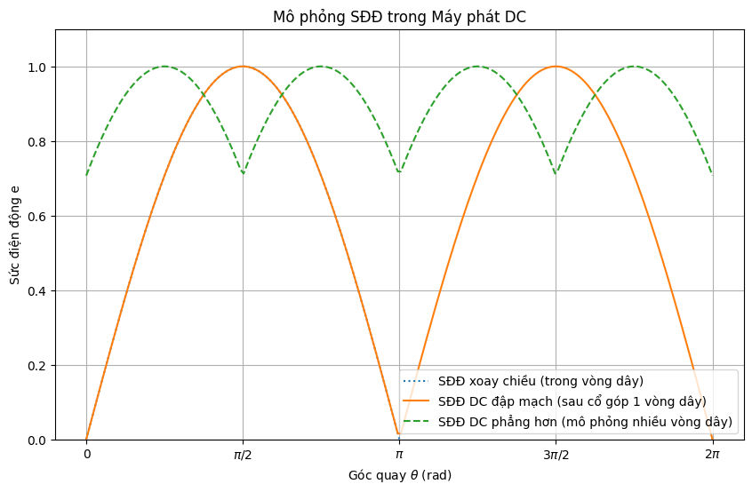

```python
import numpy as np
import matplotlib.pyplot as plt
import math # Cần cho pi

# --- Mô phỏng dạng sóng SĐĐ ---
# Tạo trục thời gian (hoặc góc quay)
theta = np.linspace(0, 2 * np.pi, 200) # Một chu kỳ (0 đến 360 độ)

# SĐĐ xoay chiều trong 1 vòng dây (hình sin)
e_ac = np.sin(theta)

# SĐĐ một chiều đập mạch sau cổ góp (giá trị tuyệt đối của hình sin)
e_dc_pulsating = np.abs(np.sin(theta))

# SĐĐ DC phẳng hơn (mô phỏng tổng của nhiều vòng dây lệch pha)
# Ví dụ: Tổng của 2 vòng dây lệch nhau 90 độ
e_dc_smoother = np.abs(np.sin(theta)) + np.abs(np.sin(theta + np.pi/2))
# Chuẩn hóa biên độ để dễ so sánh
if np.max(e_dc_smoother) > 0: # not div for 0
    e_dc_smoother = e_dc_smoother / np.max(e_dc_smoother) * np.max(e_dc_pulsating)
else:
    e_dc_smoother = np.zeros_like(theta)


# --- Vẽ đồ thị ---
print("\n--- Đồ thị mô phỏng SĐĐ Máy phát DC ---")
plt.figure(figsize=(10, 6))

plt.plot(theta, e_ac, label='SĐĐ xoay chiều (trong vòng dây)', linestyle=':')
plt.plot(theta, e_dc_pulsating, label='SĐĐ DC đập mạch (sau cổ góp 1 vòng dây)')
plt.plot(theta, e_dc_smoother, label='SĐĐ DC phẳng hơn (mô phỏng nhiều vòng dây)', linestyle='--')

plt.title('Mô phỏng SĐĐ trong Máy phát DC')
plt.xlabel('Góc quay $\\theta$ (rad)')
plt.ylabel('Sức điện động e')
plt.xticks(np.linspace(0, 2*np.pi, 5), ['0', '$\\pi/2$', '$\\pi$', '$3\\pi/2$', '$2\\pi$'])
plt.grid(True)
plt.legend()
plt.ylim(bottom=0) # Bắt đầu trục y từ 0 cho dạng DC
plt.axhline(0, color='black', linewidth=0.5) # Vẽ trục hoành
plt.show()
print("-" * 40)
```

### 5. Nguyên lý hoạt động Động cơ DC

- **Tạo Moment quay:** Hoạt động của động cơ DC dựa trên nguyên lý lực điện từ. Khi đặt một điện áp một chiều $V_t$ vào hai đầu chổi than, dòng điện $I_a$ sẽ chạy từ chổi than dương, qua các phiến góp, vào các thanh dẫn của dây quấn phần ứng nằm trong từ trường $\Phi$ của các cực từ chính, rồi qua các phiến góp khác và ra chổi than âm.
- Theo **Quy tắc bàn tay trái**, các thanh dẫn mang dòng điện $I_a$ nằm dưới các cực từ khác nhau (N và S) sẽ chịu tác dụng của các lực điện từ $F_e$ có chiều ngược nhau. Cặp lực này tạo thành một **moment quay (Torque)**, làm cho rotor (phần ứng) quay.
- **Vai trò của Cổ góp:** Tương tự như máy phát, cổ góp đóng vai trò cực kỳ quan trọng. Khi rotor quay, cổ góp sẽ đổi nối các thanh dẫn với chổi than sao cho các thanh dẫn nằm dưới một cực từ nhất định luôn có dòng điện chạy theo một chiều xác định (ví dụ: luôn đi vào dưới cực N, luôn đi ra dưới cực S). Điều này đảm bảo rằng chiều của lực điện từ tác dụng lên các thanh dẫn dưới mỗi cực từ không đổi, và do đó, **moment quay tác dụng lên rotor luôn theo một chiều**, giúp động cơ quay liên tục. Nếu không có cổ góp (dùng vành trượt), moment sẽ đổi chiều sau mỗi nửa vòng quay và động cơ không thể quay liên tục được.
- **Sức phản điện động (Back EMF / Counter EMF - CEMF):** Khi rotor của động cơ quay trong từ trường, các thanh dẫn của dây quấn phần ứng cũng cắt các đường sức từ. Theo **Quy tắc bàn tay phải** (nguyên lý máy phát), một sức điện động $E_a$ sẽ được cảm ứng trong dây quấn phần ứng. Sức điện động này có chiều **ngược lại** với chiều điện áp đặt vào $V_t$ (theo định luật Lenz) nên được gọi là sức phản điện động.
- **Ý nghĩa của $E_a$:** Sức phản điện động $E_a$ đóng vai trò tự điều chỉnh tốc độ của động cơ. Nó phụ thuộc vào từ thông $\Phi$ và tốc độ quay $\omega$ ($E_a = k\Phi\omega$). Phương trình cân bằng điện áp của phần ứng động cơ là: $ V_t = E_a + I_a R_a $  
  Trong đó $I_a R_a$ là sụt áp trên điện trở mạch phần ứng ($R_a$ bao gồm điện trở dây quấn phần ứng và điện trở tiếp xúc chổi than). Từ đây suy ra dòng điện phần ứng: $ I_a = \frac{V_t - E_a}{R_a} $ Khi động cơ mới khởi động, tốc độ $\omega \approx 0$ nên $E_a \approx 0$. Do đó, dòng điện khởi động $I_a = V_t / R_a$ thường rất lớn (vì $R_a$ nhỏ). Khi tốc độ động cơ tăng lên, $E_a$ tăng theo, làm cho hiệu số $(V_t - E_a)$ giảm xuống, dẫn đến dòng $I_a$ giảm xuống đến một giá trị cân bằng, phù hợp với moment tải cơ đặt lên trục động cơ.

### 6. Phản ứng phần ứng (Armature Reaction)

- Khi máy điện một chiều làm việc có tải, dòng điện $I_a$ chạy trong dây quấn phần ứng. Dòng điện này cũng tạo ra một từ trường riêng của nó, gọi là **từ trường phần ứng** hay **phản ứng phần ứng**.
- Từ trường phần ứng này vuông góc (ngang trục - quadrature axis) với từ trường chính do các cực từ kích từ tạo ra (trục dọc - direct axis), khi chổi than được đặt ở vị trí trung tính hình học.
- **Sự tương tác:** Từ trường phần ứng sẽ tương tác với từ trường kích từ chính, làm cho từ trường tổng trong khe hở không khí của máy bị biến dạng so với khi không tải ($I_a = 0$).
- **Hậu quả của Phản ứng phần ứng:**
  1. **Méo dạng từ trường:** Từ trường tổng bị yếu đi ở mép cực từ này và mạnh lên ở mép cực từ kia (theo chiều quay). Điều này làm mật độ từ thông phân bố không đều dưới mặt cực từ.
  2. **Dịch chuyển mặt trung tính:** Mặt phẳng trung tính hình học (nơi lý tưởng để đặt chổi than khi không tải, vì tại đó sđđ trong các phần tử đổi chiều bằng 0) bị lệch đi một góc so với vị trí ban đầu. Mặt trung tính thực tế (nơi từ trường tổng bằng 0) sẽ bị lệch theo chiều quay đối với động cơ và ngược chiều quay đối với máy phát. Nếu chổi than không được đặt đúng vị trí mặt trung tính thực tế, quá trình đổi chiều dòng điện trong các phần tử dây quấn nối với phiến góp sẽ khó khăn, gây ra **tia lửa điện** giữa chổi than và cổ góp, làm mòn nhanh và có thể hư hỏng máy.
  3. **Hiệu ứng khử từ:** Thành phần từ trường ngang trục của phần ứng, khi xét đến sự bão hòa của mạch từ, có thể gây ra hiệu ứng làm **suy giảm** từ thông chính $\Phi$ của máy. Mức độ suy giảm này tăng lên khi dòng tải $I_a$ tăng. Việc từ thông bị suy giảm sẽ ảnh hưởng trực tiếp đến sức điện động $E_a$ và moment $T_{dt}$ của máy ($E_a = k\Phi\omega$, $T_{dt} = k\Phi I_a$).
- **Khắc phục:** Để giảm thiểu tác hại của phản ứng phần ứng, người ta thường sử dụng:
  - **Cực từ phụ (Interpoles):** Tạo ra từ trường phụ để khử từ trường phần ứng tại vùng chổi than, cải thiện đổi chiều.
  - **Cuộn bù (Compensating Windings):** Đặt trong rãnh trên mặt cực từ chính, tạo ra từ trường ngược chiều và triệt tiêu từ trường phần ứng ngay dưới mặt cực từ.

### 7. Cực từ phụ (Interpoles) và Cuộn bù (Compensating Windings)

Phản ứng phần ứng gây ra hai vấn đề chính: làm méo dạng từ trường dưới mặt cực từ chính và làm lệch mặt trung tính gây khó khăn cho quá trình đổi chiều (đánh lửa ở chổi than). Để khắc phục các vấn đề này, đặc biệt trong các máy điện DC công suất lớn hoặc yêu cầu chất lượng đổi chiều cao, người ta sử dụng cực từ phụ và/hoặc cuộn bù.

- **a. Cực từ phụ (Interpoles / Commutating Poles):**
  - **Cấu tạo:** Là các cực từ nhỏ đặt xen kẽ giữa các cực từ chính. Dây quấn của các cực từ phụ có số vòng ít nhưng tiết diện lớn, được **nối nối tiếp** với dây quấn phần ứng (và cuộn bù nếu có).
  - **Nguyên lý hoạt động:** Mục đích chính của cực từ phụ là **cải thiện quá trình đổi chiều** (commutation). Khi dòng điện phần ứng $I_a$ chạy qua dây quấn cực từ phụ, nó tạo ra một từ trường phụ $\Phi_{ctp}$ tại vùng chổi than (vùng đổi chiều).
  - **Phân cực:** Cực tính của cực từ phụ được thiết kế sao cho từ trường $\Phi_{ctp}$ nó tạo ra:
    - **Chống lại** từ trường do phản ứng phần ứng gây ra tại vùng đổi chiều.
    - **Cảm ứng một sức điện động đổi chiều ($e_{rot}$) trong các phần tử dây quấn đang đổi chiều.** Sức điện động này có chiều ngược lại với sức điện động tự cảm ($e_{L} = -L \frac{di}{dt}$) sinh ra do sự biến thiên nhanh của dòng điện trong phần tử đó khi đổi chiều.
    - **Quy tắc xác định cực tính:**
      - **Máy phát:** Cực từ phụ có cực tính **giống** cực từ chính **tiếp theo** theo chiều quay.
      - **Động cơ:** Cực từ phụ có cực tính **giống** cực từ chính **phía sau** nó theo chiều quay (hoặc ngược với cực từ chính tiếp theo).
  - **Ưu điểm:** Vì dây quấn cực từ phụ nối nối tiếp với phần ứng, từ trường $\Phi_{ctp}$ nó tạo ra tỉ lệ với dòng $I_a$. Điều này rất có lợi vì sức điện động tự cảm $e_L$ cũng tỉ lệ với $I_a$. Do đó, cực từ phụ có thể tự động tạo ra sđđ đổi chiều phù hợp với nhiều mức tải khác nhau, giúp quá trình đổi chiều diễn ra tốt hơn và giảm đáng kể tia lửa điện ở chổi than. Hầu hết các máy điện DC hiện đại (trừ các máy rất nhỏ) đều có cực từ phụ.
- **b. Cuộn bù (Compensating Windings):**
  - **Cấu tạo:** Là các thanh dẫn hoặc cuộn dây đặt trong các rãnh xẻ trên bề mặt của các cực từ chính. Cuộn bù cũng được **nối nối tiếp** với dây quấn phần ứng.
  - **Nguyên lý hoạt động:** Mục đích chính của cuộn bù là **chống lại trực tiếp ảnh hưởng của từ trường phần ứng ngay dưới mặt các cực từ chính**. Dòng điện $I_a$ chạy qua cuộn bù theo chiều ngược lại với chiều dòng điện trong các thanh dẫn phần ứng đối diện nó. Do đó, từ trường do cuộn bù tạo ra sẽ gần như triệt tiêu từ trường ngang trục do phần ứng gây ra trong vùng dưới mặt cực từ.
  - **Tác dụng:** Việc này giúp:
    - Giảm sự méo dạng của từ trường chính.
    - Ngăn chặn sự bão hòa cục bộ ở các mép cực từ khi tải lớn hoặc thay đổi đột ngột.
    - Giữ cho sự phân bố từ thông dưới mặt cực từ ổn định hơn.
  - **Ứng dụng:** Cuộn bù có cấu tạo phức tạp và đắt tiền hơn nên thường chỉ được sử dụng trong các máy điện DC công suất rất lớn hoặc các máy làm việc ở chế độ tải nặng, thay đổi đột ngột (như động cơ máy cán thép) để đảm bảo sự ổn định và chất lượng làm việc cao.

## II. Phân tích Máy phát một chiều

### II.1. Thí nghiệm không tải và Đặc tính không tải (OCC)

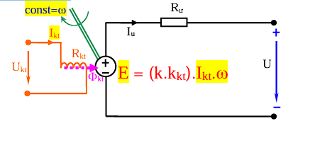

```
--- Vẽ đồ thị OCC từ dữ liệu mẫu ---
   (Đồ thị) Độ dốc Air-gap line (ước lượng từ điểm 2) = 180.00 V/A
```

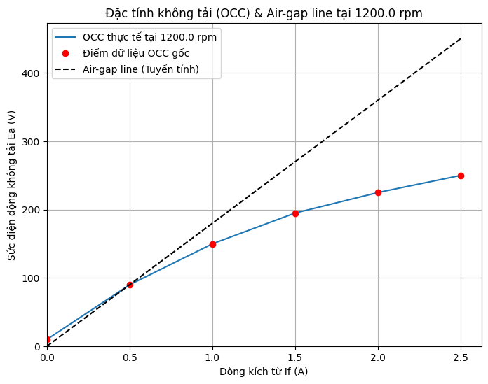

```python
# Import thư viện cần thiết
import numpy as np
import matplotlib.pyplot as plt
import math

# --- Dataset sample occ ---
If_occ_data = np.array([0.0, 0.5, 1.0, 1.5, 2.0, 2.5])  # Ampe
Ea_occ_data = np.array([10.0, 90.0, 150.0, 195.0, 225.0, 250.0]) # Volt
n0_occ_speed = 1200.0 # Tốc độ đo OCC (rpm)
# ---------------------------------------------------------

# --- Vẽ đồ thị OCC ---
print("\n--- Vẽ đồ thị OCC từ dữ liệu mẫu ---")
plt.figure(figsize=(8, 6)) # Kích thước cửa sổ đồ thị

# Kiểm tra xem có đủ dữ liệu để vẽ không
if If_occ_data.size >= 2 and Ea_occ_data.size >= 2:
    # Vẽ đường OCC thực tế (nội suy mượt)
    # Tạo ra nhiều điểm If hơn để đường cong mượt
    If_smooth = np.linspace(If_occ_data.min(), If_occ_data.max(), 300)
    # Nội suy giá trị Ea tương ứng cho các điểm If_smooth
    Ea_smooth = np.interp(If_smooth, If_occ_data, Ea_occ_data)
    plt.plot(If_smooth, Ea_smooth, label=f'OCC thực tế tại {n0_occ_speed} rpm')
    # Đánh dấu các điểm dữ liệu gốc đã nhập
    plt.plot(If_occ_data, Ea_occ_data, 'ro', label='Điểm dữ liệu OCC gốc')

    # --- Vẽ đường Air-gap line ---
    # Ước lượng độ dốc từ điểm dữ liệu thứ hai (tránh điểm từ dư nếu If=0, Ea>0)
    # Chọn điểm đầu tiên sau gốc tọa độ để tính độ dốc tuyến tính
    # Tìm index của điểm đầu tiên có If > 0
    first_positive_if_index = -1
    for i in range(len(If_occ_data)):
        if If_occ_data[i] > 1e-6: # Kiểm tra If > 0 (tránh chia cho 0)
            first_positive_if_index = i
            break

    if first_positive_if_index != -1:
        slope_air_gap = Ea_occ_data[first_positive_if_index] / If_occ_data[first_positive_if_index]
        print(f"   (Đồ thị) Độ dốc Air-gap line (ước lượng từ điểm {first_positive_if_index+1}) = {slope_air_gap:.2f} V/A")
        # Vẽ đường thẳng từ gốc tọa độ với độ dốc này, kéo dài đến If tối đa
        If_air_gap_line = np.array([0, If_occ_data.max()]) # Điểm đầu và cuối của đường thẳng
        Ea_air_gap_line = slope_air_gap * If_air_gap_line
        plt.plot(If_air_gap_line, Ea_air_gap_line, 'k--', label='Air-gap line (Tuyến tính)')
    else:
        print("   Không thể vẽ Air-gap line do thiếu điểm dữ liệu phù hợp (If > 0).")
    # ---------------------------

else:
    # Hiển thị thông báo nếu không đủ dữ liệu
    plt.text(0.5, 0.5, 'Chưa có đủ dữ liệu OCC (cần ít nhất 2 điểm)',
             horizontalalignment='center', verticalalignment='center',
             transform=plt.gca().transAxes) # Đặt text ở giữa đồ thị

# --- Định dạng đồ thị ---
plt.title(f'Đặc tính không tải (OCC) & Air-gap line tại {n0_occ_speed} rpm') # Tiêu đề
plt.xlabel('Dòng kích từ If (A)') # Nhãn trục hoành
plt.ylabel('Sức điện động không tải Ea (V)') # Nhãn trục tung
plt.grid(True) # Hiển thị lưới
plt.legend() # Hiển thị chú giải các đường
plt.ylim(bottom=0) # Bắt đầu trục tung từ 0
plt.xlim(left=0) # Bắt đầu trục hoành từ 0
plt.show() # Hiển thị cửa sổ đồ thị
print("-" * 40)
```

### II.2. Máy phát DC kích từ độc lập (Separately Excited DC Generator)

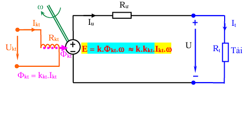

- **a. Sơ đồ mạch và Nguyên lý:**
  - Đây là loại máy phát mà mạch kích từ được cấp nguồn bởi một nguồn DC bên ngoài, hoàn toàn độc lập với mạch phần ứng của máy phát.
  - **Mạch kích từ:** Gồm nguồn $V_f$ và tổng điện trở mạch kích từ $R_f$ (bao gồm điện trở cuộn dây $R_{f\_coil}$ và biến trở điều chỉnh $R_{adj}$ nếu có). Dòng kích từ được xác định bởi: $$ I_f = \frac{V_f}{R_f} $$
  - **Mạch phần ứng:** Khi máy phát quay bởi động cơ sơ cấp với tốc độ góc $\omega$, sức điện động $E_a$ được cảm ứng trong dây quấn phần ứng. $E_a$ phụ thuộc vào từ thông $\Phi$ (do $I_f$ tạo ra) và tốc độ $\omega$: $$ E_a = k \Phi \omega $$ (Trong đó $k$ là hằng số cấu tạo của máy). Nếu mạch từ chưa bão hòa, $\Phi$ tỉ lệ với $I_f$, nên $E_a \approx k' I_f \omega$. Nếu mạch từ bão hòa, mối quan hệ $E_a = f(I_f)$ tại một tốc độ $\omega_0$ được xác định bởi đường cong OCC.
  - Khi nối mạch phần ứng với tải $R_{load}$, dòng điện phần ứng $I_a$ chạy ra tải. Do kích từ độc lập, dòng tải $I_L$ chính bằng dòng phần ứng: $I_L = I_a$.
  - **Phương trình cân bằng điện áp:** Điện áp đầu cực $V_t$ cấp cho tải được xác định bởi: $$ V_t = E_a - I_a R_a $$ Trong đó $R_a$ là tổng điện trở mạch phần ứng (bao gồm điện trở dây quấn phần ứng, điện trở tiếp xúc chổi than, điện trở cực từ phụ và cuộn bù nếu có).
- **b. Đặc tính (External Characteristic):**
  - Đặc tính biểu diễn mối quan hệ giữa điện áp đầu cực $V_t$ và dòng điện tải $I_L$ (hay $I_a$) khi tốc độ quay $\omega$ và dòng kích từ $I_f$ (do đó cả từ thông $\Phi$) được giữ không đổi: $V_t = f(I_L)$ với $\omega=const, I_f=const$.
  - Từ phương trình $V_t = E_a - I_a R_a$, vì $E_a = k\Phi\omega$ là hằng số trong điều kiện này, nên $V_t$ giảm tuyến tính khi $I_a$ tăng.
  - $V_t = E_a|_{I_f, \omega} - R_a I_L$
  - Đây là một đường thẳng dốc xuống. Độ dốc của đường đặc tính ngoài phụ thuộc vào điện trở phần ứng $R_a$. $R_a$ càng nhỏ, đặc tính càng "cứng" (ít dốc).
  - Nếu xét thêm ảnh hưởng của phản ứng phần ứng (làm giảm $\Phi$ khi $I_a$ tăng), thì $E_a$ sẽ giảm nhẹ khi $I_a$ tăng, làm cho đường đặc tính ngoài thực tế hơi cong xuống và dốc hơn so với đường thẳng lý thuyết.
- **c. Giản đồ công suất:**
  - **Công suất cơ vào:** $P_{co} = T_{co} \omega$ (Công suất từ động cơ sơ cấp)
  - **Tổn hao quay:** $P_{rot}$ (Tổn hao cơ do ma sát, quạt gió + Tổn hao sắt từ trong lõi phần ứng)
  - **Công suất điện từ:** $P_{dt} = P_{co} - P_{rot} = E_a I_a$ (Công suất chuyển đổi từ cơ sang điện trong phần ứng)
  - **Tổn hao đồng phần ứng:** $P_{Cu,a} = I_a^2 R_a$
  - **Công suất điện đầu ra (ra tải):** $P_{out} = P_{dt} - P_{Cu,a} = V_t I_L = V_t I_a$
  - **Công suất kích từ (từ nguồn riêng):** $P_f = V_f I_f = I_f^2 R_f$
  - **Tổng công suất vào:** $P_{in} = P_{co} + P_f$
  - **Hiệu suất:** $\eta = \frac{P_{out}}{P_{in}} = \frac{P_{out}}{P_{co} + P_f}$
- **d. Hàm Python tính toán (Ví dụ cho trường hợp tuyến tính hoặc đã biết Ea):**

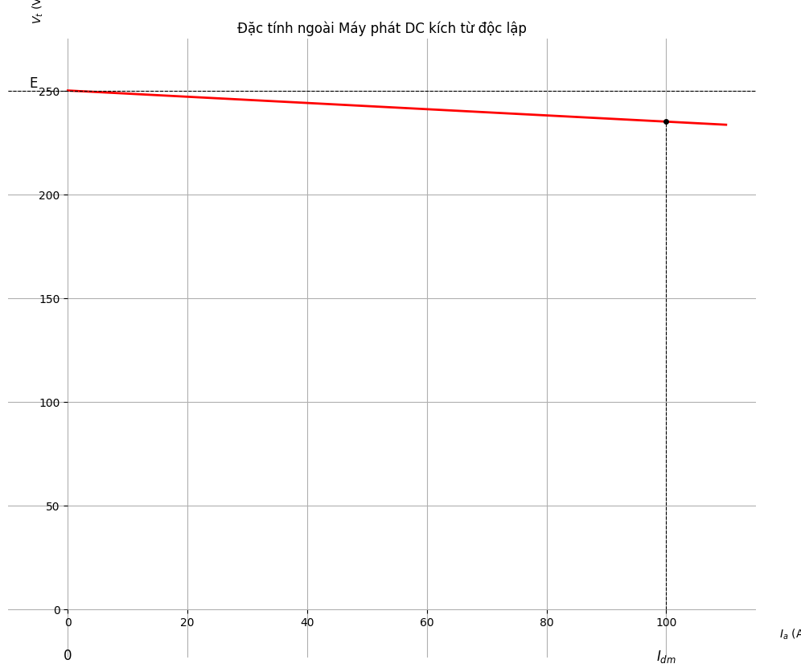

```python
import numpy as np
import matplotlib.pyplot as plt

# --- Giả định các thông số cho ví dụ ---
Ea = 250.0  # Sức điện động không tải (V) - Giả sử không đổi
Ra = 0.15   # Điện trở phần ứng (Ohm)
Ia_dm = 100.0 # Dòng phần ứng định mức (A)

# --- Tính toán các điểm trên đặc tính ngoài ---
# Tạo một dải dòng điện phần ứng từ 0 đến định mức (hoặc hơn một chút)
Ia_values = np.linspace(0, Ia_dm * 1.1, 100) # Vẽ đến 110% định mức
# Tính điện áp đầu cực tương ứng: Vt = Ea - Ia*Ra
Vt_values = Ea - Ia_values * Ra

# Tính điện áp tại dòng định mức
Vt_at_Idm = Ea - Ia_dm * Ra

# --- Vẽ đồ thị ---
plt.figure(figsize=(12, 10)) # Kích thước cửa sổ đồ thị

# Vẽ đường đặc tính ngoài
plt.plot(Ia_values, Vt_values, 'r-', linewidth=2, label='$V_t = E_a - I_a R_a$')

# --- Thêm các đường gióng và nhãn giống hình ảnh ---
# Đường gióng ngang tại Ea
plt.axhline(y=Ea, color='k', linestyle='--', linewidth=0.8)
plt.text(-Ia_dm*0.05, Ea, 'E', fontsize=12, verticalalignment='bottom', horizontalalignment='right') # Nhãn E

# Đường gióng ngang tại Vt=0 (trục hoành) - đã có trục
# Đường gióng đứng tại Ia=0 (trục tung) - đã có trục

# Đường gióng đứng tại Ia_dm
plt.vlines(x=Ia_dm, ymin=0, ymax=Vt_at_Idm, color='k', linestyle='--', linewidth=0.8)
# Đường gióng ngang từ điểm (Ia_dm, Vt_at_Idm) về trục tung (không có trong hình gốc nhưng có thể thêm nếu muốn)
# plt.hlines(y=Vt_at_Idm, xmin=0, xmax=Ia_dm, color='k', linestyle=':', linewidth=0.8)

# Đánh dấu điểm định mức
plt.plot(Ia_dm, Vt_at_Idm, 'ko', markersize=4) # Chấm tròn đen nhỏ tại điểm định mức

# --- Định dạng đồ thị ---
plt.title('Đặc tính ngoài Máy phát DC kích từ độc lập') # Tiêu đề
plt.xlabel('$I_a$ (A)') # Nhãn trục hoành (sử dụng Ia thay vì Iu)
plt.ylabel('$V_t$ (V)') # Nhãn trục tung (sử dụng Vt thay vì U)

# Đặt giới hạn trục và vị trí các nhãn trục
plt.xlim(left=-Ia_dm*0.1, right=Ia_dm * 1.15) # Bắt đầu trục x hơi âm để thấy gốc
plt.ylim(bottom=-Vt_at_Idm*0.1, top=Ea * 1.1) # Bắt đầu trục y hơi âm

# Thêm các nhãn 0, Idm, U (Vt)
plt.text(0, -Vt_at_Idm*0.08, '0', fontsize=12, verticalalignment='top', horizontalalignment='center')
plt.text(Ia_dm, -Vt_at_Idm*0.08, '$I_{dm}$', fontsize=12, verticalalignment='top', horizontalalignment='center')
# plt.text(-Ia_dm*0.05, Vt_at_Idm, 'U', fontsize=12, verticalalignment='center', horizontalalignment='right') # Có thể thêm nếu muốn

plt.grid(True) # Hiển thị lưới
# plt.legend() # Có thể bỏ chú giải nếu muốn giống hệt hình
plt.box(False) # Ẩn khung bao quanh đồ thị
plt.gca().spines['left'].set_position('zero') # Di chuyển trục tung vào gốc
plt.gca().spines['bottom'].set_position('zero') # Di chuyển trục hoành vào gốc
plt.gca().spines['right'].set_color('none') # Ẩn trục phải
plt.gca().spines['top'].set_color('none') # Ẩn trục trên

# Điều chỉnh vị trí các tick label để không chồng lấn gốc 0
plt.gca().xaxis.set_ticks_position('bottom')
plt.gca().yaxis.set_ticks_position('left')
plt.gca().xaxis.set_label_coords(1.05, 0.05) # Điều chỉnh vị trí nhãn trục X
plt.gca().yaxis.set_label_coords(0.05, 1.05) # Điều chỉnh vị trí nhãn trục Y
```

**Ví dụ 13a:**

Một máy phát DC kích từ độc lập có:

- Dòng phần ứng định mức: $I_{a,dm} = 5$ A
- Điện trở phần ứng: $R_a = 0.5$ Ω
- Dòng điện kích từ (ở đk không tải & định mức ban đầu): $I_{f0} = 2.1$ A
- Điện trở kích từ: $R_f = 10$ Ω
- Tốc độ (ở đk không tải & định mức ban đầu): $n_0 = 1600$ vòng/phút
- Tổn hao quay (cơ + sắt từ): $P_{rot} = 40$ W
- Điện áp không tải (tại $I_{f0}, n_0$): $V_0 = E_0 = 120$ V

**Yêu cầu:**

Ở chế độ định mức:

- a. Tính điện áp và công suất tiêu thụ trên tải? ($V_t, P_{out}$)
- b. Tính công suất điện từ và moment điện từ? ($P_{dt}, T_{dt}$)
- c. Tính công suất cơ và moment cơ? ($P_{co}, T_{co}$)
- d. Tính hiệu suất? ($\eta$)

Giả sử mạch từ tuyến tính, tải có điện trở $R_t = 23.5$ Ω, tính điện áp trên tải của máy phát khi:

- e. Dòng kích từ tăng lên $I_{f1} = 2.8$ A (tốc độ $n=1600$ rpm)?
- f. Dòng kích từ là $I_{f2} = 2.32$ A và tốc độ giảm xuống còn $n_2 = 1450$ vòng/phút?

```
--- BÀI GIẢI BÀI TẬP 13a BẰNG PYTHON ---
========================================
1. Thông số đã cho:
   Ia định mức = 5.0 A
   Ra = 0.5 Ohm
   If ban đầu (If0) = 2.1 A
   Rf = 10.0 Ohm
   Tốc độ ban đầu (n0) = 1600.0 rpm
   Tổn hao quay (Prot) = 40.0 W
   Sđđ không tải (E0) = 120.0 V
   Điện trở tải (Rt) = 23.5 Ohm (cho câu e,f)
========================================
2. Tính toán sơ bộ:
   Tốc độ góc ban đầu (omega0) = 167.5516 rad/s
   Hằng số máy (kPhi0) tại If0 = 0.7162 V.s/rad (Nm/A)
========================================
3. Câu a: Điện áp và công suất tải ở định mức
   Ea (định mức) = 120.00 V
   Vt = Ea - Ia*Ra = 120.00 - 5.0*0.5 = 117.50 V
   Pout = Vt * Ia = 117.50 * 5.0 = 587.50 W
========================================
4. Câu b: Công suất và moment điện từ ở định mức
   Pdt = Ea * Ia = 120.00 * 5.0 = 600.00 W
   Tdt = Pdt / omega0 = 600.00 / 167.5516 = 3.581 Nm
========================================
5. Câu c: Công suất và moment cơ ở định mức
   Pco = Pdt + Prot = 600.00 + 40.0 = 640.00 W
   Tco = Pco / omega0 = 640.00 / 167.5516 = 3.820 Nm
========================================
6. Câu d: Hiệu suất ở định mức
   Công suất kích từ (Pf) = If0^2 * Rf = 2.1^2 * 10.0 = 44.10 W
   Tổng công suất vào (Pin) = Pco + Pf = 640.00 + 44.10 = 684.10 W
   Công suất đầu ra (Pout) = 587.50 W
   => Hiệu suất (eta) = (Pout / Pin) * 100% = 85.88 %
========================================
7. Câu e: Tính Vt khi If=2.8A, n=1600rpm, Rt=23.5 Ohm
   Giả sử tuyến tính: kPhi1 = kPhi0 * (If1/If0) = 0.7162 * (2.8/2.1) = 0.9549 V.s/rad
   Sức điện động mới (Ea1) = kPhi1 * omega1 = 0.9549 * 167.5516 = 160.00 V
   Dòng phần ứng mới (Ia1) = Ea1 / (Ra + Rt) = 160.00 / (0.5 + 23.5) = 6.667 A
   => Điện áp tải mới (Vt1) = Ia1 * Rt = 6.667 * 23.5 = 156.67 V
========================================
8. Câu f: Tính Vt khi If=2.32A, n=1450rpm, Rt=23.5 Ohm
   Tốc độ góc mới (omega2) = 151.8436 rad/s
   Giả sử tuyến tính: kPhi2 = kPhi0 * (If2/If0) = 0.7162 * (2.32/2.1) = 0.7912 V.s/rad
   Sức điện động mới (Ea2) = kPhi2 * omega2 = 0.7912 * 151.8436 = 120.14 V
   Dòng phần ứng mới (Ia2) = Ea2 / (Ra + Rt) = 120.14 / (0.5 + 23.5) = 5.006 A
   => Điện áp tải mới (Vt2) = Ia2 * Rt = 5.006 * 23.5 = 117.64 V
========================================
9. Vẽ đồ thị Đặc tính ngoài
```

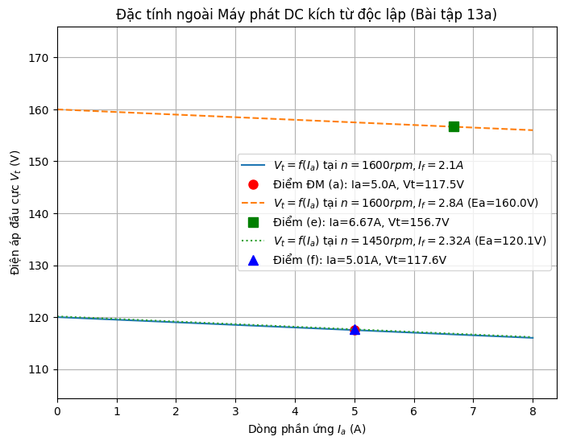

```
--- KẾT THÚC ---
```

```python
# Import thư viện cần thiết
import math
import numpy as np
import matplotlib.pyplot as plt

# --- 1. Khai báo thông số ban đầu từ đề bài 13a ---
Ia_dm = 5.0  # Dòng phần ứng định mức (A)
Ra = 0.5     # Điện trở phần ứng (Ohm)
If0 = 2.1    # Dòng kích từ ban đầu (A)
Rf = 10.0    # Điện trở kích từ (Ohm)
n0 = 1600.0  # Tốc độ ban đầu (vòng/phút - rpm)
Prot = 40.0  # Tổn hao quay (W)
E0 = 120.0   # Sđđ không tải tại If0, n0 (V)
Rt = 23.5    # Điện trở tải cho câu e, f (Ohm)

print("--- BÀI GIẢI BÀI TẬP 13a BẰNG PYTHON ---")
print("="*40)
print("1. Thông số đã cho:")
print(f"   Ia định mức = {Ia_dm} A")
print(f"   Ra = {Ra} Ohm")
print(f"   If ban đầu (If0) = {If0} A")
print(f"   Rf = {Rf} Ohm")
print(f"   Tốc độ ban đầu (n0) = {n0} rpm")
print(f"   Tổn hao quay (Prot) = {Prot} W")
print(f"   Sđđ không tải (E0) = {E0} V")
print(f"   Điện trở tải (Rt) = {Rt} Ohm (cho câu e,f)")
print("="*40)

# --- 2. Tính toán sơ bộ ---
omega0 = (2 * math.pi * n0) / 60
kPhi0 = E0 / omega0 if omega0 != 0 else None

print("2. Tính toán sơ bộ:")
print(f"   Tốc độ góc ban đầu (omega0) = {omega0:.4f} rad/s")
if kPhi0 is not None:
    print(f"   Hằng số máy (kPhi0) tại If0 = {kPhi0:.4f} V.s/rad (Nm/A)")
else:
    print("   Lỗi: Không tính được kPhi0 do omega0 = 0.")
    # Thoát nếu không tính được kPhi0 vì các bước sau cần nó
    exit()
print("="*40)

# --- 3. Giải câu a: Điện áp và công suất tải ở định mức ---
print("3. Câu a: Điện áp và công suất tải ở định mức")
Ea_a = E0
Ia_a = Ia_dm
Vt_a = Ea_a - Ia_a * Ra
Pout_a = Vt_a * Ia_a
print(f"   Ea (định mức) = {Ea_a:.2f} V")
print(f"   Vt = Ea - Ia*Ra = {Ea_a:.2f} - {Ia_a:.1f}*{Ra} = {Vt_a:.2f} V")
print(f"   Pout = Vt * Ia = {Vt_a:.2f} * {Ia_a:.1f} = {Pout_a:.2f} W")
print("="*40)

# --- 4. Giải câu b: Công suất và moment điện từ ở định mức ---
print("4. Câu b: Công suất và moment điện từ ở định mức")
Pdt_b = Ea_a * Ia_a
Tdt_b = Pdt_b / omega0
print(f"   Pdt = Ea * Ia = {Ea_a:.2f} * {Ia_a:.1f} = {Pdt_b:.2f} W")
print(f"   Tdt = Pdt / omega0 = {Pdt_b:.2f} / {omega0:.4f} = {Tdt_b:.3f} Nm")
print("="*40)

# --- 5. Giải câu c: Công suất và moment cơ ở định mức ---
print("5. Câu c: Công suất và moment cơ ở định mức")
Pco_c = Pdt_b + Prot
Tco_c = Pco_c / omega0
print(f"   Pco = Pdt + Prot = {Pdt_b:.2f} + {Prot:.1f} = {Pco_c:.2f} W")
print(f"   Tco = Pco / omega0 = {Pco_c:.2f} / {omega0:.4f} = {Tco_c:.3f} Nm")
print("="*40)

# --- 6. Giải câu d: Hiệu suất ở định mức ---
print("6. Câu d: Hiệu suất ở định mức")
Pf_d = If0**2 * Rf
Pin_d = Pco_c + Pf_d
eta_d = (Pout_a / Pin_d) * 100 if Pin_d != 0 else 0
print(f"   Công suất kích từ (Pf) = If0^2 * Rf = {If0:.1f}^2 * {Rf:.1f} = {Pf_d:.2f} W")
print(f"   Tổng công suất vào (Pin) = Pco + Pf = {Pco_c:.2f} + {Pf_d:.2f} = {Pin_d:.2f} W")
print(f"   Công suất đầu ra (Pout) = {Pout_a:.2f} W")
print(f"   => Hiệu suất (eta) = (Pout / Pin) * 100% = {eta_d:.2f} %")
print("="*40)

# --- 7. Giải câu e: Tính Vt khi If=2.8A, n=1600rpm, Rt=23.5 Ohm ---
print("7. Câu e: Tính Vt khi If=2.8A, n=1600rpm, Rt=23.5 Ohm")
If1_e = 2.8
n1_e = 1600.0
omega1_e = omega0 # Tốc độ không đổi

kPhi1_e = kPhi0 * (If1_e / If0)
Ea1_e = kPhi1_e * omega1_e
Ia1_e = Ea1_e / (Ra + Rt)
Vt1_e = Ia1_e * Rt
print(f"   Giả sử tuyến tính: kPhi1 = kPhi0 * (If1/If0) = {kPhi0:.4f} * ({If1_e}/{If0}) = {kPhi1_e:.4f} V.s/rad")
print(f"   Sức điện động mới (Ea1) = kPhi1 * omega1 = {kPhi1_e:.4f} * {omega1_e:.4f} = {Ea1_e:.2f} V")
print(f"   Dòng phần ứng mới (Ia1) = Ea1 / (Ra + Rt) = {Ea1_e:.2f} / ({Ra} + {Rt}) = {Ia1_e:.3f} A")
print(f"   => Điện áp tải mới (Vt1) = Ia1 * Rt = {Ia1_e:.3f} * {Rt} = {Vt1_e:.2f} V")
print("="*40)

# --- 8. Giải câu f: Tính Vt khi If=2.32A, n=1450rpm, Rt=23.5 Ohm ---
print("8. Câu f: Tính Vt khi If=2.32A, n=1450rpm, Rt=23.5 Ohm")
If2_f = 2.32
n2_f = 1450.0
omega2_f = (2 * math.pi * n2_f) / 60

kPhi2_f = kPhi0 * (If2_f / If0)
Ea2_f = kPhi2_f * omega2_f
Ia2_f = Ea2_f / (Ra + Rt)
Vt2_f = Ia2_f * Rt
print(f"   Tốc độ góc mới (omega2) = {omega2_f:.4f} rad/s")
print(f"   Giả sử tuyến tính: kPhi2 = kPhi0 * (If2/If0) = {kPhi0:.4f} * ({If2_f}/{If0}) = {kPhi2_f:.4f} V.s/rad")
print(f"   Sức điện động mới (Ea2) = kPhi2 * omega2 = {kPhi2_f:.4f} * {omega2_f:.4f} = {Ea2_f:.2f} V")
print(f"   Dòng phần ứng mới (Ia2) = Ea2 / (Ra + Rt) = {Ea2_f:.2f} / ({Ra} + {Rt}) = {Ia2_f:.3f} A")
print(f"   => Điện áp tải mới (Vt2) = Ia2 * Rt = {Ia2_f:.3f} * {Rt} = {Vt2_f:.2f} V")
print("="*40)

# --- 9. Vẽ đồ thị Đặc tính ngoài Vt = f(Ia) ---
print("9. Vẽ đồ thị Đặc tính ngoài")

plt.figure(figsize=(8, 6))

# --- Vẽ đặc tính ngoài ứng với điều kiện ban đầu (If0, n0) ---
# Tạo dải dòng Ia
Ia_max_plot = max(Ia_a, Ia1_e, Ia2_f) * 1.2 # Vẽ rộng hơn điểm lớn nhất đã tính
Ia_plot = np.linspace(0, Ia_max_plot, 100)
# Tính Vt tương ứng: Vt = E0 - Ia*Ra (vì Ea=E0 ở n0, If0)
Vt_plot_0 = E0 - Ia_plot * Ra
plt.plot(Ia_plot, Vt_plot_0, label=f'$V_t = f(I_a)$ tại $n={n0:.0f}rpm, I_f={If0:.1f}A$')
# Đánh dấu điểm định mức (câu a)
plt.plot(Ia_a, Vt_a, 'ro', markersize=8, label=f'Điểm ĐM (a): Ia={Ia_a:.1f}A, Vt={Vt_a:.1f}V')

# --- Vẽ đặc tính ngoài ứng với điều kiện câu e (If1, n1=n0) ---
# Ea = Ea1_e = 160V
Vt_plot_1 = Ea1_e - Ia_plot * Ra
plt.plot(Ia_plot, Vt_plot_1, label=f'$V_t = f(I_a)$ tại $n={n1_e:.0f}rpm, I_f={If1_e:.1f}A$ (Ea={Ea1_e:.1f}V)', linestyle='--')
# Đánh dấu điểm làm việc câu e
plt.plot(Ia1_e, Vt1_e, 'gs', markersize=8, label=f'Điểm (e): Ia={Ia1_e:.2f}A, Vt={Vt1_e:.1f}V')

# --- Vẽ đặc tính ngoài ứng với điều kiện câu f (If2, n2) ---
# Ea = Ea2_f = 120.14V
Vt_plot_2 = Ea2_f - Ia_plot * Ra
plt.plot(Ia_plot, Vt_plot_2, label=f'$V_t = f(I_a)$ tại $n={n2_f:.0f}rpm, I_f={If2_f:.2f}A$ (Ea={Ea2_f:.1f}V)', linestyle=':')
# Đánh dấu điểm làm việc câu f
plt.plot(Ia2_f, Vt2_f, 'b^', markersize=8, label=f'Điểm (f): Ia={Ia2_f:.2f}A, Vt={Vt2_f:.1f}V')


# --- Định dạng đồ thị ---
plt.title('Đặc tính ngoài Máy phát DC kích từ độc lập (Bài tập 13a)')
plt.xlabel('Dòng phần ứng $I_a$ (A)')
plt.ylabel('Điện áp đầu cực $V_t$ (V)')
plt.grid(True)
plt.legend()
plt.xlim(left=0)
plt.ylim(bottom=min(Vt_plot_0.min(), Vt_plot_1.min(), Vt_plot_2.min()) * 0.9, top=max(E0, Ea1_e, Ea2_f) * 1.1) # Điều chỉnh giới hạn y
plt.show()

print("--- KẾT THÚC ---")
```